# Getting Started with Tabular Data

Fall R ’23

Dominic Bordelon, Research Data Librarian, ULS

## Agenda

1. What are R and RStudio? What can you do with them?
2. R as a calculator
3. RStudio orientation
4. Packages
5. Loading data
6. R data types and structures
7. Saving data

## About the trainer

**Dominic Bordelon, Research Data Librarian**  
University Library System, University of Pittsburgh  
dbordelon@pitt.edu

Services for the Pitt community:

- Consultations
- Training (on-request and via public workshops)
- Talks (on-request and publicly)
- Research collaboration

Support areas and interests:

- Computer programming fundamentals, esp. for data processing and analysis
- Open Science and Data Sharing
- Data stewardship/curation
- Research methods; science and technology studies

## Fall R Series

| # | Date | Title |
| --- | --- | --- |
| 1 | 8/29 | Getting Started with Tabular Data |
| 2 | 9/5 | Working with Data Frames |
| 3 | 9/12 | Data Visualization |
| 4 | 9/19 | Inference and Modeling Intro |
| 5 | 9/26 | Machine Learning Intro |

## What to expect

- I strongly don’t believe in “sink or swim” or the weed-out mentality—reach out if you need help!
- How will we use our time?
  - Some lecturing with slides
  - Practice with hands-on Exercises; work in couples/groups (recommended) or independently
- You/we might not finish all the exercises in the allotted time; that’s OK.
- There is no homework *per se*, but I suggest to practice applying what we learn to your own data between sessions. I also plan to share suggested reading for each session.

# Thinking about data

## Basic formats of data

- string or character-based data
  - viewable/editable in a text processor
  - may consist of plain text or specially encoded information (markup languages, tabular formats)
- image, audio, video, and sensor data
  - requires additional layers of software for viewing and editing
  - various encoding schemes depending on electronic source and desired use case
- compressed data
  - one of the above types with some bits removed
  - compression may be “lossy” or “lossless”
  - decompression may occur on-the-fly (playing an MP3) or may need to be accomplished before consuming data (a zip file)

## Ways to work with data

- Tabular format – quantitative, statistical methods
- Document format (XML) – qualitative methods
- Computer vision and audition – algorithmic processing, deep learning models

In this course, we are working with string data—interpreted as numeric values and pieces of text—in a tabular format.

# What are R and RStudio? What can you do with them?

## What are R and RStudio?

**R** is…

- a tool for statistical analysis and visualization dating back to 1993
- a general-purpose programming language
- text-based command interface $\rightarrow$ it runs on the console/command line
- free, open-source software (FOSS) stewarded by the nonprofit, Vienna-based R Foundation

**RStudio (Desktop)** is…

- an “integrated development environment”—graphical interface with numerous features—for analysis and programming in R and Python
- Posit (until recently, called RStudio) is a Boston-based public benefit corporation, founded 2009; makes both FOSS and commercial software and offers hosted services

## What can you do with R and RStudio?

- Import data from file and online sources
- Explore, clean, reformat, and combine data
- Perform calculations and analyses on data, especially using statistical methods
- Visualize data
- Present information in a variety of formats (documents, Web, etc.)
- Build a dashboard or other web app, especially interacting with tabular data

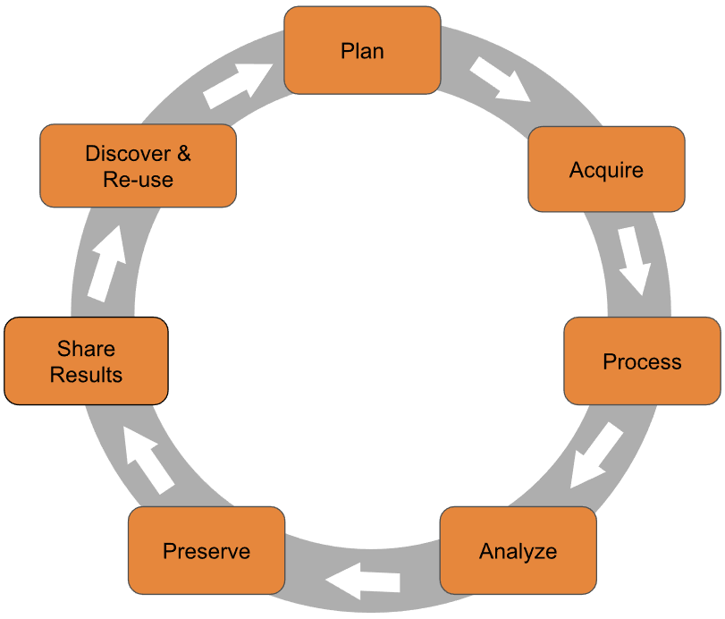

Research Data Lifecycle; source: [Princeton Research Data Service](https://researchdata.princeton.edu/research-lifecycle-guide/research-lifecycle-guide)

## Why I prefer R

**versus Excel:**

✅ Non-proprietary, open source  
✅ Powerful and fast interactions with data  
✅ Very extensible  
✅ Research-oriented community  
✅ Reproducible and visible interactions with data  
✅ Data viz makes sense to me  
✅ Can handle more data for a given quantity of system resources  
✅ Less prone to accidental user error

❌ R has a steeper learning curve  
❌ R/RStudio doesn’t have convenient data entry

**versus Python:**

✅ Purpose-built for stats  
✅ Simpler mental model and syntax (for tabular data work)  
✅ RStudio is better than (free) IDEs for Python  
✅ I can always call Python from within R if I need to

❌ R has a smaller (but more focused) community with less published code

# R as a calculator

## Our first R code

- When you open RStudio, you’ll see the console. This is where R waits for commands.
- Arithmetic operators: **`+ - * / ^`** (exponentiation) `%%` (modulus) `%/%` (integer division)
- As in algebra, an R **function** accepts *arguments* and returns a *value*.
- Common mathematical functions: `sum(), mean(), median(), mode(), min(), max(), sd(), sqrt(), abs()`
- Logarithms: `log(x)` for natural and `log10(x)` for base 10 (or `log(x, base)` for any base you want)
- $e$ (Euler’s number) is represented with `exp(1)`, where `1` is the desired exponent of $e$.
- Rounding: `round()` for decimal places, `signif()` for specifiying significant digits
  - See also: `floor()`, `ceiling()`
- NOTE: To operate on more than one value, such as calculating a mean, your values need to be inside a *vector*.

## Vectors in R

- An ordered collection of values, all having the same type (e.g., numeric or text)
- Created with the **`c()`** function (“combine”)
- R *loves* vectors—so much, that any single value you give to R, is returned as a 1-length vector!
- Very many operations are *vectorized*, meaning that they apply to every value in a vector by default.

# Exercise 1.1: console calculations

# RStudio orientation

## RStudio layout (panes)

**▟ TL: Source/Editor 📝**

Write *scripts* and *R notebooks* in tabs

**▜ BL: Console 👩‍💻**

Run commands  
⬆ for command history  
⭾ tab key for suggestions

**▙ TR: Environment, History 🌐**

*Objects* in your *workspace* (session); Import Dataset

**▛ BR: Help, Files, Packages ❓🔍📦**

All extremely useful!

## What kinds of files will you use in RStudio? (1)

- **R Notebook** (**.Rmd**) or **Quarto document** (**.qmd**): mix formatted text and code and code outputs
- **R script** (**.R**): plain-text file that can be executed by R directly
  - ⚠ The only permitted “natural language” is in code comments.
- [**R Project**](https://support.rstudio.com/hc/en-us/articles/200526207-Using-RStudio-Projects) (**.Rproj**): lives in the directory for a given project, and holds information like command history and settings. Optional but recommended.
- .**RData**: a workspace (session) snapshot
- **.rds**: an R data structure, i.e., an R object which has been saved to the filesystem

## What kinds of files will you use in RStudio? (2)

Of course, you will also be loading files in whatever format your data take (spreadsheets, shapefiles, etc.).

Protip: make sure your operating system is set to display *all* file extensions!

- [Windows instructions](https://support.microsoft.com/en-us/windows/common-file-name-extensions-in-windows-da4a4430-8e76-89c5-59f7-1cdbbc75cb01)
- [macOS instructions](https://support.apple.com/guide/mac-help/show-or-hide-filename-extensions-on-mac-mchlp2304/mac#:~:text=On%20your%20Mac%2C%20select%20a,or%20deselect%20%E2%80%9CHide%20extension.%E2%80%9D)

## Ways to run your session

- Console: quick calculations, one-line pieces of code
- Scripts: multiple console commands saved in one file
  - You can send to console line-by-line, or entire file at once
- Notebooks: a document with “code chunks” (mini scripts)
  - You can run the chunk one line at a time, or entire chunk at once

**Keyboard shortcuts**

Windows:

- **Ctrl-Enter** runs one line of code
- **Ctrl-Shift-Enter** runs the whole chunk

Mac:

- **⌘-Enter** runs one line of code
- **⌘-Shift-Enter** runs the whole chunk

## Working Directory (1)

- Suppose your project folder has a subfolder called `data`, and a file called `patients.csv`.
  - Absolute path: `/users/djb190/Documents/projects/R/study-x/data/patients.csv`
  - Relative path: `data/patients.csv`
- We would rather use the relative path, but R needs to know, “relative to where?”

## Working Directory (2)

- Use **`getwd()`** to check your current working directory
- To set your working directory:
  - In the **Files** tab (bottom right), click the three dots **…** at right, find the folder you would like to use as Working Directory, and click Open
  - Now click the **⚙More▾** button and choose **Set As Working Directory**
- When you run a script, you should set the working directory
- When you open a notebook, RStudio will automatically treat the notebook’s location as the working directory

# Packages

## Packages 📦

- Packages are additional functionality created by individuals and collaborations in the R user community
- So far, we have only used **base R**
- Packages greatly extend R! You’ll use them *all the time*.
- The authoritative place for packages is **CRAN**, the Comprehensive R Archive Network (https://cran.r-project.org/)
  - A convenient directory and repository
  - QA/QC process; trusted as reliable and safe

## Install a package

1. Google “Rstats $x$” where $x$ is whatever you want to do (or maybe “R package for $x$”). Read about available packages for your job and choose one.
2. Go to Packages tab (bottom right pane ▛) and click Install.
3. Type the name of the package you want and click install.

Or if you like to write code: `install.packages("name-of-package")`

Let’s install the **tidyverse**, a collection of packages that we’ll use for the rest of the course: **`install.packages("tidyverse")`**

## Attach a package

- To use a package, we need to *attach* it:
  - In Packages tab, click the checkbox next to the package name
  - or run `library(package-name)`
- Once a package is attached, its functions and/or datasets are available in the workspace. (But all packages are detached when the session ends.)
- Some packages will display a message or warning when they attach; some will not; depending on the package and your setup

Now let’s attach tidyverse: **`library(tidyverse)`**

# Loading data

## Tabular data

You are likely to encounter tabular data in the following storage formats:

- Comma-separated values (**CSV**) or tab-separated values (TSV): `.csv, .tsv, .dat, .txt`
- Excel spreadsheets: `.xlsx, .xls`
- OpenDocument spreadsheet from OpenOffice/LibreOffice: `.ods`
- Parquet, a columnar format which is very efficient: `.parquet`
- Relational databases: usually via remote connection
  - Requires writing structured query language (SQL) or using a SQL-based package.

We are going to focus on CSV, since it is a non-proprietary and extremely common format.

## Loading a CSV

- readr is a package for reading CSVs and other character-delimited formats
  - (also possible with base R, but readr is recommended)
- `library(readr)` will attach readr, but it is included in tidyverse (which we already have attached)
- This means we can call readr’s `read_csv()` function!
- You can also call a function from an installed package, without attaching it, by prepending the package name and two colons: `readr::read_csv()`.

[figure not shown]

## Object assignment

In order to do something with our data, besides look at them once, we need to tell R to *assign* the result of our expression—i.e., the output of `read_csv()`—to an object. We also sometimes call this *storing* or *saving* an object

**Keyboard shortcuts**

Windows:

**Alt -** (alt-hyphen) inserts an assignment operator, `<-`

Mac:

**⌥ -** (option-hyphen) inserts an assignment operator, `<-`

You may also use **`=`** (equals) for object assignment, although it is not recommended.

## Viewing the data

Use the **`View()`** function on our loaded data to launch the Data Viewer, for example: **`View(my_values)`**. This is the same as clicking the object’s name in the Environment pane.

You can also type the object’s name to see a brief textual representation of it, in the console or notebook.

A few more useful functions:

- `dplyr::glimpse()` or `str()` shows all columns listed top-to-bottom
- `head()` and `tail()` shows the top or bottom of the data frame
- 💡 `summary()` summarizes a vector (or each vector in a data frame) according to its data type

# R data types and structures

## Data types

Every value in R has one of these types:

- `numeric`: real, decimal numbers
- `integer`: whole numbers
- `character`: text; should always be in quotation marks `" "` in code
- `logical`: `TRUE` and `FALSE`, also called Boolean
- `complex`: for imaginary values i.e. complex numbers (rare)
- `raw`: values are stored as bytes and not human-readable (rare)

## Data structures

Regardless of type, every value is organized into a structure (usually with other values). These are the most common structures:

- **Vector**: we have already used this ordered collection of single type; R’s default structure; 1D
- **List**: ordered collection of varying types; 1D
- **Data frame**: a tabular structure; 2D
  - “table” and “data.table” are two alternatives to data frames with different use cases
- Matrix (2D), Array ($n$D): Used for linear algebra, and some machine learning algorithms operate on matrices
- A special vector is the **factor**, which allows only certain values (defined in the structure); used for categorical variables
- Model object: produced by a modeling function such as linear regression
- Many other specialized structures are offered by packages, built upon these components

## The data frame

- A table in which each column (“variable”) is a vector of equal length
- Row $n$ (or “case” or “observation” $n$ ) is read by retrieving the $n$th value of each variable
- To reference a variable/column, use the format `data_frame$var_name`
- We’ll be spending the rest of our time in this course with data frames and vectors.
- (Under the hood, a data frame is a list with some added features.)

# Saving data

## Writing a CSV

- readr can also write: **`write_csv()`**
- Remember Working Directory and relative paths.
- The file name must be in quotation marks, e.g., **`write_csv("patients.csv")`**

The data frame is the “R-native” representation of the data. We read and write to an interchange format (CSV) to save and/or share our work.

# Exercise 1.2: loading and addressing data

# Wrap up

## Conclusion

We learned about:

- Orienting to R and RStudio
- Performing basic calculations and function calls
- Opening, viewing, and saving data
- Writing our first R code 😎

Next time: exploring data frames!

[figure not shown]

R 1: Getting Started with Tabular Data